# Logistic Regression and Linear Discriminant Analysis

Classification with Logistic Regression and LDA

```r
require(dplyr)
require(readr)
require(caret)
require(pROC)
load('../../../data/2018flights.Rdata')
flightsNotCancelled = df %>%
  filter(CANCELLED == 0) %>%
  na.omit

# Let's clean up the name space to free up memory
rm(df)
```

Let’s create a training/test split and relabel the supervisor to have more expressive level names:

```r
Y                 = flightsNotCancelled$DEP_DEL15
set.seed(2)
trainingDataIndex = createDataPartition(Y, p=.5, list = FALSE)
trainingData      = flightsNotCancelled[trainingDataIndex,]
testingData       = flightsNotCancelled[-trainingDataIndex,]

Xtrain = select(trainingData, -DEP_DEL15)
Xtest  = select(testingData, -DEP_DEL15)
Ytrain = factor(select(trainingData, DEP_DEL15) %>% unlist(), labels = c('ontime','delay'))
Ytest  = factor(select(testingData, DEP_DEL15) %>% unlist(), labels = c('ontime','delay'))

rm(trainingData)
rm(testingData)
```

I want to be able to predict whether there is a departure delay based on the month and the carrier:

```r
Xtrain = select(Xtrain, MONTH, OP_UNIQUE_CARRIER) %>% mutate_all(factor)
Xtest  = select(Xtest, MONTH, OP_UNIQUE_CARRIER) %>% mutate_all(factor)

str(Xtrain)
```

```
## 'data.frame':    3535909 obs. of  2 variables:
##  $ MONTH            : Factor w/ 12 levels "1","2","3","4",..: 1 1 1 1 1 1 1 1 1 1 ...
##  $ OP_UNIQUE_CARRIER: Factor w/ 18 levels "9E","AA","AS",..: 14 14 14 14 14 14 14 14 14 14 ...
```

```r
#Note: we can put the number of unique values with the data structure:
sapply(Xtrain, levels)
```

```
## $MONTH
##  [1] "1"  "2"  "3"  "4"  "5"  "6"  "7"  "8"  "9"  "10" "11" "12"
##
## $OP_UNIQUE_CARRIER
##  [1] "9E" "AA" "AS" "B6" "DL" "EV" "F9" "G4" "HA" "MQ" "NK" "OH" "OO" "UA"
## [15] "VX" "WN" "YV" "YX"
```

```r
sapply(Xtest, levels)
```

```
## $MONTH
##  [1] "1"  "2"  "3"  "4"  "5"  "6"  "7"  "8"  "9"  "10" "11" "12"
##
## $OP_UNIQUE_CARRIER
##  [1] "9E" "AA" "AS" "B6" "DL" "EV" "F9" "G4" "HA" "MQ" "NK" "OH" "OO" "UA"
## [15] "VX" "WN" "YV" "YX"
```

## 0.3 Dummy variables

```r
dummyModel = dummyVars(~ ., data = Xtrain, fullRank = TRUE)

XtrainFull = predict(dummyModel, Xtrain)
XtestFull  = predict(dummyModel, Xtest)
```

# Logistic Regression

Let’s go through and make a predictive model out of logistic regression and also look at the estimate coefficients. Remember to:

- trainControl to only train the model by setting method = ‘none’
- make sure ‘train’ treats the first level as the event of interest, which is in alphabetical order. So, ‘no’ would be the event. However, we usually want to code results so that the outcome of interest is the event. We can make this adjustment in R via ‘relevel’ on the supervisor

```r
YtrainRelevel = relevel(Ytrain, ref = 'delay')
YtestRelevel  = relevel(Ytest, ref = 'delay')

trControl    = trainControl(method = 'none')
outLogistic  = train(x = XtrainFull, y = YtrainRelevel,
                   method = 'glm', trControl = trControl)
```

Let’s look at how well calibrated the probabilities are:

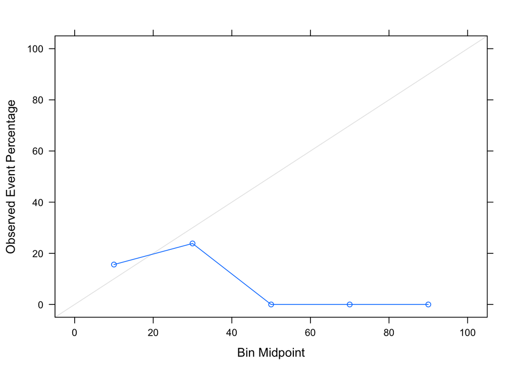

```r
YhatTestProb = predict(outLogistic, XtestFull, type = 'prob')
calibProbs = calibration(YtestRelevel ~ YhatTestProb$delay, cuts = 5)
xyplot(calibProbs)
```

```r
sum(YhatTestProb$delay > .4)
```

```
## [1] 0
```

The smaller values of the probability estimates are well calibrated. However, we don’t predict any probabilities larger than around 0.35. This isn’t an indication of poor model; hopefully there isn’t a large probability of a delay!

# Getting classifications

Let’s get some classifications. Of course, the default threshold (0.5) won’t work. So, let’s directly look at the ROC curve

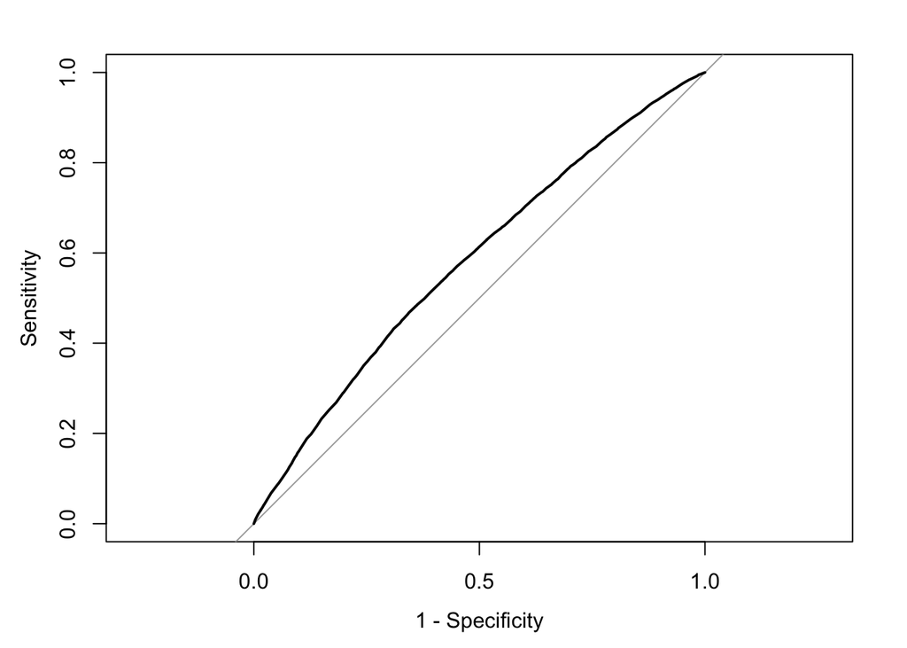

```r
rocCurve = roc(Ytest, YhatTestProb$delay)
plot(rocCurve, legacy.axes=TRUE)
```

This ROC curve doesn’t look as good as others we have seen thus far. This is undoubtably a more difficult classification problem. The area under the curve (AUC) reinforces the plot with a one number summary

```r
rocCurve$auc
```

```
## Area under the curve: 0.5823
```

```r
thresholds = rocCurve$thresholds

sort(thresholds)[1:3]
```

```
## [1]       -Inf 0.06140383 0.06413692
```

```r
sort(thresholds, decreasing = TRUE)[1:3]
```

```
## [1]       Inf 0.3408101 0.3370825
```

Notice that the threshold only varies in a sensible range based on the probability estimates. Let’s find the threshold that results in a sensitivity of .5.

```r
pt5         = which.min(rocCurve$sensitivities >= 0.5)
threshold   = thresholds[pt5]
specificity = rocCurve$specificities[pt5]
sensitivity = rocCurve$sensitivities[pt5]
```

The sensitivity for this choice is 0.4985662 and the specificity is 0.6222534.

Let’s get the classifications for this threshold

```r
YhatTestThresh = ifelse(YhatTestProb$delay > threshold,
                           'delay', 'ontime')  %>%
     as.factor %>%
     relevel(ref = 'delay')
```

We can just look at the generic output for the confusionMatrix function:

```r
confusionMatrixOut = confusionMatrix(reference = YtestRelevel, data = YhatTestThresh)
confusionMatrixOut
```

```
## Confusion Matrix and Statistics
##
##           Reference
## Prediction   delay  ontime
##     delay   323386 1090659
##     ontime  325246 1796618
##
##                Accuracy : 0.5996
##                  95% CI : (0.5991, 0.6001)
##     No Information Rate : 0.8166
##     P-Value [Acc > NIR] : 1
##
##                   Kappa : 0.0829
##
##  Mcnemar's Test P-Value : <2e-16
##
##             Sensitivity : 0.49857
##             Specificity : 0.62225
##          Pos Pred Value : 0.22870
##          Neg Pred Value : 0.84672
##              Prevalence : 0.18344
##          Detection Rate : 0.09146
##    Detection Prevalence : 0.39991
##       Balanced Accuracy : 0.56041
##
##        'Positive' Class : delay
##
```

Printing all this output is bad form as we should only be including things that we are interested in. We can grab a subset of the out via selecting individual objects:

```r
print(confusionMatrixOut$table)
```

```
##           Reference
## Prediction   delay  ontime
##     delay   323386 1090659
##     ontime  325246 1796618
```

```r
print(confusionMatrixOut$overall[1:2])
```

```
##   Accuracy      Kappa
## 0.59956407 0.08289673
```

```r
print(confusionMatrixOut$byClass[1:2])
```

```
## Sensitivity Specificity
##   0.4985662   0.6222534
```

# Linear Discriminant Analysis (LDA)

Let’s do the same thing for LDA. One of the benefits of the caret package is the code should be nearly identical.

```r
trControl = trainControl(method = 'none')
outLDA    = train(x = XtrainFull, y = YtrainRelevel,
                  method = 'lda', trControl = trControl)
```

Now, we will run through the same steps as above, but this time for LDA

```r
YhatTestProb = predict(outLDA, XtestFull, type = 'prob')
```

A calibration plot:

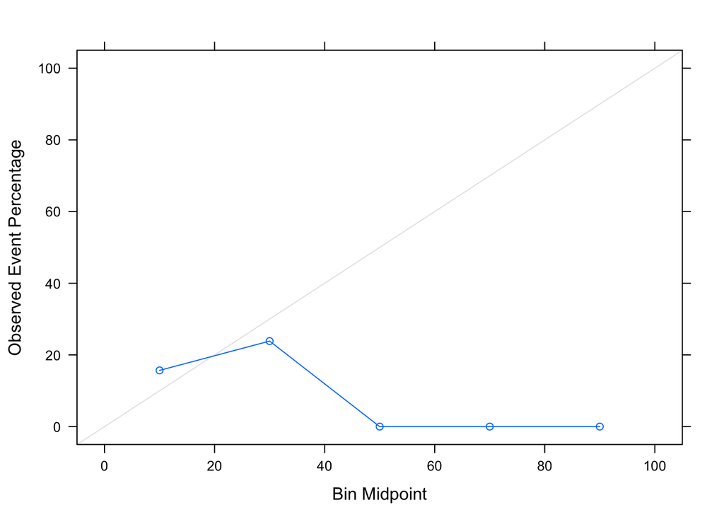

```r
calibProbs = calibration(YtestRelevel ~ YhatTestProb$delay, cuts = 5)
xyplot(calibProbs)
```

The ROC curve and AUC

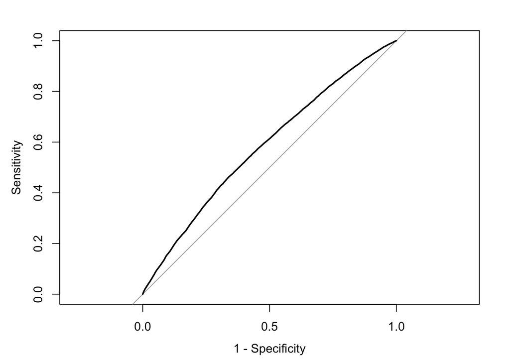

```r
rocCurve = roc(Ytest, YhatTestProb$delay)
plot(rocCurve, legacy.axes=TRUE)
```

```r
rocCurve$auc
```

```
## Area under the curve: 0.5824
```

Let’s again get the classifier with 0.5 test sensisitivity

```r
thresholds = rocCurve$thresholds

pt5         = which.min(rocCurve$sensitivities > 0.5)
threshold   = thresholds[pt5]
specificity = rocCurve$specificities[pt5]
sensitivity = rocCurve$sensitivities[pt5]
```

The specificity is 0.6267833.

Let’s get the classifications for this threshold

```r
YhatTestThresh = ifelse(YhatTestProb$delay > threshold,
                           'delay', 'ontime')  %>%
     as.factor %>%
     relevel(ref = 'delay')
```

A confusion matrix:

```r
confusionMatrixOut = confusionMatrix(reference = YtestRelevel, data = YhatTestThresh)

print(confusionMatrixOut$table)
```

```
##           Reference
## Prediction   delay  ontime
##     delay   320609 1077580
##     ontime  328023 1809697
```

```r
print(confusionMatrixOut$overall[1:2])
```

```
##   Accuracy      Kappa
## 0.60247761 0.08361092
```

```r
print(confusionMatrixOut$byClass[1:2])
```

```
## Sensitivity Specificity
##   0.4942849   0.6267833
```

# Interpreting results

Reminder: we can interpret the underlying model of logistic regression as:

- ‘A one unit change in x_j is associated with a beta_j change in the log odds that Y = C_1, holding all other features constant’

or

- ‘A one unit change in x_j is associated with a multiplicative exp{beta_j} change in the odds that Y = C_1, holding all other features constant’

Let’s do an example. Suppose I’m interested in the carrier ‘AA’ (American airlines). We can look at the relationship between delay and this carrier via logistic regression

```r
betaHat = outLogistic$finalModel$coefficients
betaHat
```

```
##          (Intercept)              MONTH.2              MONTH.3
##          1.577448753         -0.014646774          0.097754005
##              MONTH.4              MONTH.5              MONTH.6
##          0.053417407         -0.081577143         -0.238158932
##              MONTH.7              MONTH.8              MONTH.9
##         -0.271416556         -0.251773295          0.175395144
##             MONTH.10             MONTH.11             MONTH.12
##          0.189411766         -0.003802421          0.005977874
## OP_UNIQUE_CARRIER.AA OP_UNIQUE_CARRIER.AS OP_UNIQUE_CARRIER.B6
##         -0.043046619          0.353414598         -0.534086382
## OP_UNIQUE_CARRIER.DL OP_UNIQUE_CARRIER.EV OP_UNIQUE_CARRIER.F9
##          0.271096926         -0.058230409         -0.656152356
## OP_UNIQUE_CARRIER.G4 OP_UNIQUE_CARRIER.HA OP_UNIQUE_CARRIER.MQ
##         -0.239294805          0.967082417          0.036239607
## OP_UNIQUE_CARRIER.NK OP_UNIQUE_CARRIER.OH OP_UNIQUE_CARRIER.OO
##          0.099483884         -0.176724552          0.089947613
## OP_UNIQUE_CARRIER.UA OP_UNIQUE_CARRIER.VX OP_UNIQUE_CARRIER.WN
##          0.030174479         -0.012207610         -0.308987291
## OP_UNIQUE_CARRIER.YV OP_UNIQUE_CARRIER.YX
##          0.007711533          0.129314371
```

So, the relevant part is:

```r
betaHatAA = betaHat[13]
exp(betaHat[13])
```

```
## OP_UNIQUE_CARRIER.AA
##            0.9578667
```

Of course, it doesn’t make sense to think of a ‘one unit change’ in an airline. The interpretation of the parameter will be relative to the left out category for the dummy variable (this will by default be the first level alphabetically)

```r
levels(Xtrain$OP_UNIQUE_CARRIER)
```

```
##  [1] "9E" "AA" "AS" "B6" "DL" "EV" "F9" "G4" "HA" "MQ" "NK" "OH" "OO" "UA"
## [15] "VX" "WN" "YV" "YX"
```

Note that we can look at differences between two levels as well:

```r
betaHatJuly = betaHat[7]
betaHatOct  = betaHat[10]
exp(betaHatJuly)
```

```
##   MONTH.7
## 0.7622989
```

```r
exp(betaHatOct)
```

```
## MONTH.10
## 1.208538
```

```r
exp(betaHatJuly - betaHatOct)
```

```
##  MONTH.7
## 0.630761
```